# Risk Factor Analysis

## Outcome Variable

**Outcome Variable:** stunted

## Predictor Variables

**Intervention Variable:** sex

**Adjustment Set:**

unadjusted

## Stratifying Variables

The analysis was stratified on these variable(s):

- agecat
- studyid
- country

## Data Summary

| agecat | studyid | country | sex | stunted | n_cell | n |
| --- | --- | --- | --- | --- | --- | --- |
| Birth | ki0047075b-MAL-ED | BANGLADESH | Female | 0 | 105 | 257 |
| Birth | ki0047075b-MAL-ED | BANGLADESH | Female | 1 | 26 | 257 |
| Birth | ki0047075b-MAL-ED | BANGLADESH | Male | 0 | 105 | 257 |
| Birth | ki0047075b-MAL-ED | BANGLADESH | Male | 1 | 21 | 257 |
| Birth | ki0047075b-MAL-ED | BRAZIL | Female | 0 | 80 | 191 |
| Birth | ki0047075b-MAL-ED | BRAZIL | Female | 1 | 13 | 191 |
| Birth | ki0047075b-MAL-ED | BRAZIL | Male | 0 | 90 | 191 |
| Birth | ki0047075b-MAL-ED | BRAZIL | Male | 1 | 8 | 191 |
| Birth | ki0047075b-MAL-ED | INDIA | Female | 0 | 95 | 206 |
| Birth | ki0047075b-MAL-ED | INDIA | Female | 1 | 15 | 206 |
| Birth | ki0047075b-MAL-ED | INDIA | Male | 0 | 78 | 206 |
| Birth | ki0047075b-MAL-ED | INDIA | Male | 1 | 18 | 206 |
| Birth | ki0047075b-MAL-ED | NEPAL | Female | 0 | 78 | 173 |
| Birth | ki0047075b-MAL-ED | NEPAL | Female | 1 | 6 | 173 |
| Birth | ki0047075b-MAL-ED | NEPAL | Male | 0 | 77 | 173 |
| Birth | ki0047075b-MAL-ED | NEPAL | Male | 1 | 12 | 173 |
| Birth | ki0047075b-MAL-ED | PERU | Female | 0 | 119 | 287 |
| Birth | ki0047075b-MAL-ED | PERU | Female | 1 | 15 | 287 |
| Birth | ki0047075b-MAL-ED | PERU | Male | 0 | 134 | 287 |
| Birth | ki0047075b-MAL-ED | PERU | Male | 1 | 19 | 287 |
| Birth | ki0047075b-MAL-ED | SOUTH AFRICA | Female | 0 | 119 | 262 |
| Birth | ki0047075b-MAL-ED | SOUTH AFRICA | Female | 1 | 12 | 262 |
| Birth | ki0047075b-MAL-ED | SOUTH AFRICA | Male | 0 | 115 | 262 |
| Birth | ki0047075b-MAL-ED | SOUTH AFRICA | Male | 1 | 16 | 262 |
| Birth | ki0047075b-MAL-ED | TANZANIA, UNITED REPUBLIC OF | Female | 0 | 51 | 123 |
| Birth | ki0047075b-MAL-ED | TANZANIA, UNITED REPUBLIC OF | Female | 1 | 10 | 123 |
| Birth | ki0047075b-MAL-ED | TANZANIA, UNITED REPUBLIC OF | Male | 0 | 54 | 123 |
| Birth | ki0047075b-MAL-ED | TANZANIA, UNITED REPUBLIC OF | Male | 1 | 8 | 123 |
| Birth | ki1000108-CMC-V-BCS-2002 | INDIA | Female | 0 | 40 | 90 |
| Birth | ki1000108-CMC-V-BCS-2002 | INDIA | Female | 1 | 5 | 90 |

[output cut: 314 more lines]

The following strata were considered:

- agecat: 24 months, studyid: ki0047075b-MAL-ED, country: BANGLADESH
- agecat: 24 months, studyid: ki0047075b-MAL-ED, country: BRAZIL
- agecat: 24 months, studyid: ki0047075b-MAL-ED, country: INDIA
- agecat: 24 months, studyid: ki0047075b-MAL-ED, country: NEPAL
- agecat: 24 months, studyid: ki0047075b-MAL-ED, country: PERU
- agecat: 24 months, studyid: ki0047075b-MAL-ED, country: SOUTH AFRICA
- agecat: 24 months, studyid: ki0047075b-MAL-ED, country: TANZANIA, UNITED REPUBLIC OF
- agecat: 24 months, studyid: ki1000108-CMC-V-BCS-2002, country: INDIA
- agecat: 24 months, studyid: ki1000108-IRC, country: INDIA
- agecat: 24 months, studyid: ki1017093-NIH-Birth, country: BANGLADESH
- agecat: 24 months, studyid: ki1017093b-PROVIDE, country: BANGLADESH
- agecat: 24 months, studyid: ki1017093c-NIH-Crypto, country: BANGLADESH
- agecat: 24 months, studyid: ki1066203-TanzaniaChild2, country: TANZANIA, UNITED REPUBLIC OF
- agecat: 24 months, studyid: ki1101329-Keneba, country: GAMBIA
- agecat: 24 months, studyid: ki1113344-GMS-Nepal, country: NEPAL
- agecat: 24 months, studyid: ki1114097-CMIN, country: BANGLADESH
- agecat: 24 months, studyid: ki1114097-CMIN, country: GUINEA-BISSAU
- agecat: 24 months, studyid: ki1114097-CMIN, country: PERU
- agecat: 24 months, studyid: ki1114097-CONTENT, country: PERU
- agecat: 24 months, studyid: ki1119695-PROBIT, country: BELARUS
- agecat: 24 months, studyid: ki1126311-ZVITAMBO, country: ZIMBABWE
- agecat: 24 months, studyid: ki1135781-COHORTS, country: GUATEMALA
- agecat: 24 months, studyid: ki1135781-COHORTS, country: INDIA
- agecat: 24 months, studyid: ki1135781-COHORTS, country: PHILIPPINES
- agecat: 24 months, studyid: ki1148112-LCNI-5, country: MALAWI
- agecat: 24 months, studyid: kiGH5241-JiVitA-3, country: BANGLADESH
- agecat: 24 months, studyid: kiGH5241-JiVitA-4, country: BANGLADESH
- agecat: 6 months, studyid: ki0047075b-MAL-ED, country: BANGLADESH
- agecat: 6 months, studyid: ki0047075b-MAL-ED, country: BRAZIL
- agecat: 6 months, studyid: ki0047075b-MAL-ED, country: INDIA
- agecat: 6 months, studyid: ki0047075b-MAL-ED, country: NEPAL
- agecat: 6 months, studyid: ki0047075b-MAL-ED, country: PERU
- agecat: 6 months, studyid: ki0047075b-MAL-ED, country: SOUTH AFRICA
- agecat: 6 months, studyid: ki0047075b-MAL-ED, country: TANZANIA, UNITED REPUBLIC OF
- agecat: 6 months, studyid: ki1000108-CMC-V-BCS-2002, country: INDIA
- agecat: 6 months, studyid: ki1000108-IRC, country: INDIA
- agecat: 6 months, studyid: ki1000109-EE, country: PAKISTAN
- agecat: 6 months, studyid: ki1000109-ResPak, country: PAKISTAN
- agecat: 6 months, studyid: ki1000304b-SAS-CompFeed, country: INDIA
- agecat: 6 months, studyid: ki1000304b-SAS-FoodSuppl, country: INDIA
- agecat: 6 months, studyid: ki1017093-NIH-Birth, country: BANGLADESH
- agecat: 6 months, studyid: ki1017093b-PROVIDE, country: BANGLADESH
- agecat: 6 months, studyid: ki1017093c-NIH-Crypto, country: BANGLADESH
- agecat: 6 months, studyid: ki1066203-TanzaniaChild2, country: TANZANIA, UNITED REPUBLIC OF
- agecat: 6 months, studyid: ki1101329-Keneba, country: GAMBIA
- agecat: 6 months, studyid: ki1112895-Guatemala BSC, country: GUATEMALA
- agecat: 6 months, studyid: ki1113344-GMS-Nepal, country: NEPAL
- agecat: 6 months, studyid: ki1114097-CMIN, country: BANGLADESH
- agecat: 6 months, studyid: ki1114097-CMIN, country: BRAZIL
- agecat: 6 months, studyid: ki1114097-CMIN, country: GUINEA-BISSAU
- agecat: 6 months, studyid: ki1114097-CMIN, country: PERU
- agecat: 6 months, studyid: ki1114097-CONTENT, country: PERU
- agecat: 6 months, studyid: ki1119695-PROBIT, country: BELARUS
- agecat: 6 months, studyid: ki1126311-ZVITAMBO, country: ZIMBABWE
- agecat: 6 months, studyid: ki1135781-COHORTS, country: GUATEMALA
- agecat: 6 months, studyid: ki1135781-COHORTS, country: INDIA
- agecat: 6 months, studyid: ki1135781-COHORTS, country: PHILIPPINES
- agecat: 6 months, studyid: ki1148112-LCNI-5, country: MALAWI
- agecat: 6 months, studyid: kiGH5241-JiVitA-3, country: BANGLADESH
- agecat: 6 months, studyid: kiGH5241-JiVitA-4, country: BANGLADESH
- agecat: Birth, studyid: ki0047075b-MAL-ED, country: BANGLADESH
- agecat: Birth, studyid: ki0047075b-MAL-ED, country: BRAZIL
- agecat: Birth, studyid: ki0047075b-MAL-ED, country: INDIA
- agecat: Birth, studyid: ki0047075b-MAL-ED, country: NEPAL
- agecat: Birth, studyid: ki0047075b-MAL-ED, country: PERU
- agecat: Birth, studyid: ki0047075b-MAL-ED, country: SOUTH AFRICA
- agecat: Birth, studyid: ki0047075b-MAL-ED, country: TANZANIA, UNITED REPUBLIC OF
- agecat: Birth, studyid: ki1000108-CMC-V-BCS-2002, country: INDIA
- agecat: Birth, studyid: ki1000108-IRC, country: INDIA
- agecat: Birth, studyid: ki1000109-EE, country: PAKISTAN
- agecat: Birth, studyid: ki1000109-ResPak, country: PAKISTAN
- agecat: Birth, studyid: ki1000304b-SAS-CompFeed, country: INDIA
- agecat: Birth, studyid: ki1017093-NIH-Birth, country: BANGLADESH
- agecat: Birth, studyid: ki1017093c-NIH-Crypto, country: BANGLADESH
- agecat: Birth, studyid: ki1101329-Keneba, country: GAMBIA
- agecat: Birth, studyid: ki1114097-CMIN, country: BANGLADESH
- agecat: Birth, studyid: ki1114097-CMIN, country: BRAZIL
- agecat: Birth, studyid: ki1114097-CMIN, country: PERU
- agecat: Birth, studyid: ki1114097-CONTENT, country: PERU
- agecat: Birth, studyid: ki1119695-PROBIT, country: BELARUS
- agecat: Birth, studyid: ki1126311-ZVITAMBO, country: ZIMBABWE
- agecat: Birth, studyid: ki1135781-COHORTS, country: GUATEMALA
- agecat: Birth, studyid: ki1135781-COHORTS, country: INDIA
- agecat: Birth, studyid: ki1135781-COHORTS, country: PHILIPPINES
- agecat: Birth, studyid: kiGH5241-JiVitA-3, country: BANGLADESH
- agecat: Birth, studyid: kiGH5241-JiVitA-4, country: BANGLADESH

### Dropped Strata

Some strata were dropped due to rare outcomes:

- agecat: Birth, studyid: ki1000109-EE, country: PAKISTAN
- agecat: Birth, studyid: ki1000109-ResPak, country: PAKISTAN
- agecat: Birth, studyid: ki1017093-NIH-Birth, country: BANGLADESH
- agecat: Birth, studyid: ki1017093c-NIH-Crypto, country: BANGLADESH
- agecat: Birth, studyid: ki1114097-CMIN, country: BANGLADESH
- agecat: Birth, studyid: ki1114097-CMIN, country: BRAZIL
- agecat: Birth, studyid: ki1114097-CMIN, country: PERU
- agecat: Birth, studyid: ki1114097-CONTENT, country: PERU
- agecat: 6 months, studyid: ki0047075b-MAL-ED, country: BRAZIL
- agecat: 6 months, studyid: ki0047075b-MAL-ED, country: NEPAL
- agecat: 6 months, studyid: ki1114097-CMIN, country: BRAZIL
- agecat: 6 months, studyid: ki1114097-CONTENT, country: PERU
- agecat: 24 months, studyid: ki0047075b-MAL-ED, country: BRAZIL
- agecat: 24 months, studyid: ki1066203-TanzaniaChild2, country: TANZANIA, UNITED REPUBLIC OF
- agecat: 24 months, studyid: ki1114097-CONTENT, country: PERU

## Methods Detail

We’re interested in the causal parameters $E[Y_a]$ for all values of $a \in \mathcal{A}$. These parameters represent the mean outcome if, possibly contrary to fact, we intervened to set all units to have $A=a$. Under the randomization and positivity assumptions, these are identified by the statistical parameters $\psi_a=E_W[E_{Y|A,W}(Y|A=a,W)]$. In addition, we’re interested in the mean of $Y$, $E[Y]$ under no intervention (the observed mean). We will estimate these parameters by using SuperLearner to fit the relevant likelihood factors – $E_{Y|A,W}(Y|A=a,W)$ and $p(A=a|W)$, and then updating our likelihood fit using a joint TMLE.

For unadjusted analyses ($W=\{\}$), initial likelihoods were estimated using Lrnr_glm to estimate the simple $E(Y|A)$ and Lrnr_mean to estimate $p(A)$. For adjusted analyses, a small library containing Lrnr_glmnet, Lrnr_xgboost, and Lrnr_mean was used.

Having estimated these parameters, we will then use the delta method to estimate relative risks and attributable risks relative to a prespecified baseline level of $A$.

# Results Detail

## Results Plots

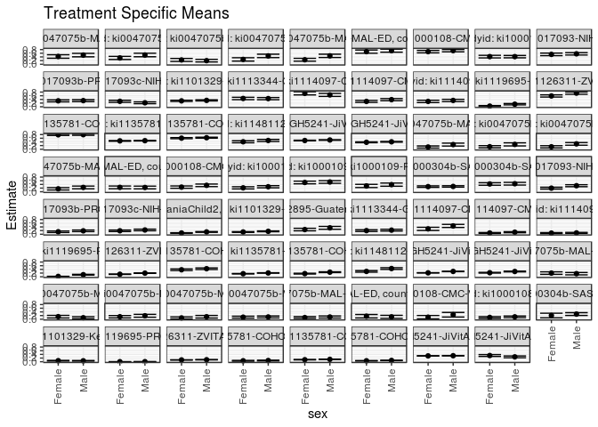

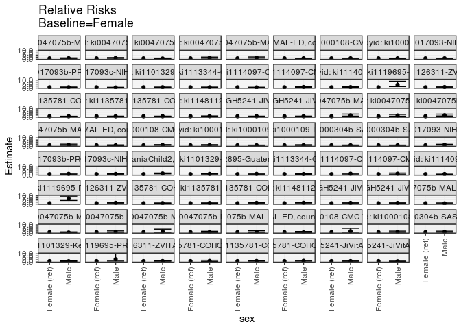

[figure not shown]

[figure not shown]

## Results Table

### Parameter: TSM

| agecat | studyid | country | intervention_level | baseline_level | estimate | ci_lower | ci_upper |
| --- | --- | --- | --- | --- | --- | --- | --- |
| Birth | ki0047075b-MAL-ED | BANGLADESH | Female | NA | 0.1984733 | 0.1300397 | 0.2669068 |
| Birth | ki0047075b-MAL-ED | BANGLADESH | Male | NA | 0.1666667 | 0.1014673 | 0.2318660 |
| Birth | ki0047075b-MAL-ED | BRAZIL | Female | NA | 0.1397849 | 0.0691239 | 0.2104460 |
| Birth | ki0047075b-MAL-ED | BRAZIL | Male | NA | 0.0816327 | 0.0272807 | 0.1359846 |
| Birth | ki0047075b-MAL-ED | INDIA | Female | NA | 0.1363636 | 0.0720766 | 0.2006506 |
| Birth | ki0047075b-MAL-ED | INDIA | Male | NA | 0.1875000 | 0.1092325 | 0.2657675 |
| Birth | ki0047075b-MAL-ED | NEPAL | Female | NA | 0.0714286 | 0.0161940 | 0.1266631 |
| Birth | ki0047075b-MAL-ED | NEPAL | Male | NA | 0.1348315 | 0.0636679 | 0.2059951 |
| Birth | ki0047075b-MAL-ED | PERU | Female | NA | 0.1119403 | 0.0584632 | 0.1654174 |
| Birth | ki0047075b-MAL-ED | PERU | Male | NA | 0.1241830 | 0.0718352 | 0.1765308 |
| Birth | ki0047075b-MAL-ED | SOUTH AFRICA | Female | NA | 0.0916031 | 0.0421110 | 0.1410951 |
| Birth | ki0047075b-MAL-ED | SOUTH AFRICA | Male | NA | 0.1221374 | 0.0659576 | 0.1783172 |
| Birth | ki0047075b-MAL-ED | TANZANIA, UNITED REPUBLIC OF | Female | NA | 0.1639344 | 0.0706496 | 0.2572193 |
| Birth | ki0047075b-MAL-ED | TANZANIA, UNITED REPUBLIC OF | Male | NA | 0.1290323 | 0.0452456 | 0.2128190 |
| Birth | ki1000108-CMC-V-BCS-2002 | INDIA | Female | NA | 0.1111111 | 0.0187752 | 0.2034470 |
| Birth | ki1000108-CMC-V-BCS-2002 | INDIA | Male | NA | 0.2444444 | 0.1181770 | 0.3707119 |
| Birth | ki1000108-IRC | INDIA | Female | NA | 0.0982659 | 0.0538513 | 0.1426805 |
| Birth | ki1000108-IRC | INDIA | Male | NA | 0.1302326 | 0.0851871 | 0.1752780 |
| Birth | ki1000304b-SAS-CompFeed | INDIA | Female | NA | 0.2023810 | 0.0778767 | 0.3268852 |
| Birth | ki1000304b-SAS-CompFeed | INDIA | Male | NA | 0.2815534 | 0.2053981 | 0.3577087 |
| Birth | ki1101329-Keneba | GAMBIA | Female | NA | 0.0569106 | 0.0401907 | 0.0736305 |
| Birth | ki1101329-Keneba | GAMBIA | Male | NA | 0.0498132 | 0.0347607 | 0.0648657 |
| Birth | ki1119695-PROBIT | BELARUS | Female | NA | 0.0011148 | 0.0002224 | 0.0020072 |
| Birth | ki1119695-PROBIT | BELARUS | Male | NA | 0.0037269 | 0.0011090 | 0.0063448 |
| Birth | ki1126311-ZVITAMBO | ZIMBABWE | Female | NA | 0.0987233 | 0.0915996 | 0.1058469 |
| Birth | ki1126311-ZVITAMBO | ZIMBABWE | Male | NA | 0.1081195 | 0.1008931 | 0.1153460 |
| Birth | ki1135781-COHORTS | GUATEMALA | Female | NA | 0.0519802 | 0.0303211 | 0.0736393 |
| Birth | ki1135781-COHORTS | GUATEMALA | Male | NA | 0.0647321 | 0.0419344 | 0.0875299 |
| Birth | ki1135781-COHORTS | INDIA | Female | NA | 0.1095462 | 0.0987156 | 0.1203767 |
| Birth | ki1135781-COHORTS | INDIA | Male | NA | 0.1283019 | 0.1171336 | 0.1394702 |

[output cut: 112 more lines]

### Parameter: E(Y)

| agecat | studyid | country | intervention_level | baseline_level | estimate | ci_lower | ci_upper |
| --- | --- | --- | --- | --- | --- | --- | --- |
| Birth | ki0047075b-MAL-ED | BANGLADESH | NA | NA | 0.1828794 | 0.1355257 | 0.2302330 |
| Birth | ki0047075b-MAL-ED | BRAZIL | NA | NA | 0.1099476 | 0.0654669 | 0.1544284 |
| Birth | ki0047075b-MAL-ED | INDIA | NA | NA | 0.1601942 | 0.1099849 | 0.2104035 |
| Birth | ki0047075b-MAL-ED | NEPAL | NA | NA | 0.1040462 | 0.0584174 | 0.1496751 |
| Birth | ki0047075b-MAL-ED | PERU | NA | NA | 0.1184669 | 0.0810142 | 0.1559196 |
| Birth | ki0047075b-MAL-ED | SOUTH AFRICA | NA | NA | 0.1068702 | 0.0693890 | 0.1443514 |
| Birth | ki0047075b-MAL-ED | TANZANIA, UNITED REPUBLIC OF | NA | NA | 0.1463415 | 0.0836232 | 0.2090597 |
| Birth | ki1000108-CMC-V-BCS-2002 | INDIA | NA | NA | 0.1777778 | 0.0983474 | 0.2572081 |
| Birth | ki1000108-IRC | INDIA | NA | NA | 0.1159794 | 0.0840777 | 0.1478811 |
| Birth | ki1000304b-SAS-CompFeed | INDIA | NA | NA | 0.2459893 | 0.1594019 | 0.3325767 |
| Birth | ki1101329-Keneba | GAMBIA | NA | NA | 0.0532122 | 0.0420018 | 0.0644226 |
| Birth | ki1119695-PROBIT | BELARUS | NA | NA | 0.0023768 | 0.0010945 | 0.0036592 |
| Birth | ki1126311-ZVITAMBO | ZIMBABWE | NA | NA | 0.1035430 | 0.0984652 | 0.1086208 |
| Birth | ki1135781-COHORTS | GUATEMALA | NA | NA | 0.0586854 | 0.0428942 | 0.0744767 |
| Birth | ki1135781-COHORTS | INDIA | NA | NA | 0.1192771 | 0.1114807 | 0.1270735 |
| Birth | ki1135781-COHORTS | PHILIPPINES | NA | NA | 0.0613115 | 0.0527962 | 0.0698268 |
| Birth | kiGH5241-JiVitA-3 | BANGLADESH | NA | NA | 0.3231530 | 0.3154984 | 0.3308077 |
| Birth | kiGH5241-JiVitA-4 | BANGLADESH | NA | NA | 0.3004866 | 0.2649179 | 0.3360553 |
| 6 months | ki0047075b-MAL-ED | BANGLADESH | NA | NA | 0.1867220 | 0.1374205 | 0.2360234 |
| 6 months | ki0047075b-MAL-ED | INDIA | NA | NA | 0.1949153 | 0.1442678 | 0.2455627 |
| 6 months | ki0047075b-MAL-ED | PERU | NA | NA | 0.2197802 | 0.1705687 | 0.2689917 |
| 6 months | ki0047075b-MAL-ED | SOUTH AFRICA | NA | NA | 0.1968504 | 0.1478551 | 0.2458457 |
| 6 months | ki0047075b-MAL-ED | TANZANIA, UNITED REPUBLIC OF | NA | NA | 0.2348178 | 0.1818480 | 0.2877876 |
| 6 months | ki1000108-CMC-V-BCS-2002 | INDIA | NA | NA | 0.3008130 | 0.2539566 | 0.3476694 |
| 6 months | ki1000108-IRC | INDIA | NA | NA | 0.2457002 | 0.2038248 | 0.2875757 |
| 6 months | ki1000109-EE | PAKISTAN | NA | NA | 0.5188172 | 0.4679751 | 0.5696593 |
| 6 months | ki1000109-ResPak | PAKISTAN | NA | NA | 0.3531915 | 0.2919518 | 0.4144312 |
| 6 months | ki1000304b-SAS-CompFeed | INDIA | NA | NA | 0.2844311 | 0.2666491 | 0.3022132 |
| 6 months | ki1000304b-SAS-FoodSuppl | INDIA | NA | NA | 0.4289474 | 0.3791199 | 0.4787748 |
| 6 months | ki1017093-NIH-Birth | BANGLADESH | NA | NA | 0.2681564 | 0.2306532 | 0.3056597 |
| 6 months | ki1017093b-PROVIDE | BANGLADESH | NA | NA | 0.1612350 | 0.1313580 | 0.1911120 |
| 6 months | ki1017093c-NIH-Crypto | BANGLADESH | NA | NA | 0.2097902 | 0.1799252 | 0.2396552 |
| 6 months | ki1066203-TanzaniaChild2 | TANZANIA, UNITED REPUBLIC OF | NA | NA | 0.0970922 | 0.0842059 | 0.1099785 |
| 6 months | ki1101329-Keneba | GAMBIA | NA | NA | 0.1412159 | 0.1262788 | 0.1561530 |
| 6 months | ki1112895-Guatemala BSC | GUATEMALA | NA | NA | 0.3010033 | 0.2489243 | 0.3530824 |
| 6 months | ki1113344-GMS-Nepal | NEPAL | NA | NA | 0.2113677 | 0.1776128 | 0.2451225 |
| 6 months | ki1114097-CMIN | BANGLADESH | NA | NA | 0.3827160 | 0.3214780 | 0.4439541 |
| 6 months | ki1114097-CMIN | GUINEA-BISSAU | NA | NA | 0.0896226 | 0.0703861 | 0.1088591 |
| 6 months | ki1114097-CMIN | PERU | NA | NA | 0.0675039 | 0.0480051 | 0.0870027 |
| 6 months | ki1119695-PROBIT | BELARUS | NA | NA | 0.0626864 | 0.0488489 | 0.0765239 |
| 6 months | ki1126311-ZVITAMBO | ZIMBABWE | NA | NA | 0.1662447 | 0.1582324 | 0.1742571 |
| 6 months | ki1135781-COHORTS | GUATEMALA | NA | NA | 0.4099896 | 0.3788775 | 0.4411017 |
| 6 months | ki1135781-COHORTS | INDIA | NA | NA | 0.1854227 | 0.1762253 | 0.1946201 |
| 6 months | ki1135781-COHORTS | PHILIPPINES | NA | NA | 0.2112260 | 0.1958496 | 0.2266024 |
| 6 months | ki1148112-LCNI-5 | MALAWI | NA | NA | 0.3682956 | 0.3356382 | 0.4009530 |
| 6 months | kiGH5241-JiVitA-3 | BANGLADESH | NA | NA | 0.2513830 | 0.2432594 | 0.2595066 |
| 6 months | kiGH5241-JiVitA-4 | BANGLADESH | NA | NA | 0.2525357 | 0.2384780 | 0.2665934 |
| 24 months | ki0047075b-MAL-ED | BANGLADESH | NA | NA | 0.4622642 | 0.3949918 | 0.5295365 |
| 24 months | ki0047075b-MAL-ED | INDIA | NA | NA | 0.4185022 | 0.3541865 | 0.4828179 |
| 24 months | ki0047075b-MAL-ED | NEPAL | NA | NA | 0.2149123 | 0.1614774 | 0.2683472 |
| 24 months | ki0047075b-MAL-ED | PERU | NA | NA | 0.3681592 | 0.3013164 | 0.4350020 |
| 24 months | ki0047075b-MAL-ED | SOUTH AFRICA | NA | NA | 0.3529412 | 0.2921001 | 0.4137823 |
| 24 months | ki0047075b-MAL-ED | TANZANIA, UNITED REPUBLIC OF | NA | NA | 0.7149533 | 0.6543278 | 0.7755787 |
| 24 months | ki1000108-CMC-V-BCS-2002 | INDIA | NA | NA | 0.7150538 | 0.6691221 | 0.7609854 |
| 24 months | ki1000108-IRC | INDIA | NA | NA | 0.4156479 | 0.3678270 | 0.4634689 |
| 24 months | ki1017093-NIH-Birth | BANGLADESH | NA | NA | 0.5547786 | 0.5076945 | 0.6018626 |
| 24 months | ki1017093b-PROVIDE | BANGLADESH | NA | NA | 0.3292894 | 0.2909105 | 0.3676684 |
| 24 months | ki1017093c-NIH-Crypto | BANGLADESH | NA | NA | 0.2568093 | 0.2190047 | 0.2946140 |
| 24 months | ki1101329-Keneba | GAMBIA | NA | NA | 0.3344928 | 0.3122213 | 0.3567642 |
| 24 months | ki1113344-GMS-Nepal | NEPAL | NA | NA | 0.4468938 | 0.4032281 | 0.4905594 |
| 24 months | ki1114097-CMIN | BANGLADESH | NA | NA | 0.6818182 | 0.6230135 | 0.7406228 |
| 24 months | ki1114097-CMIN | GUINEA-BISSAU | NA | NA | 0.3393829 | 0.2998111 | 0.3789548 |
| 24 months | ki1114097-CMIN | PERU | NA | NA | 0.3193473 | 0.2751780 | 0.3635166 |
| 24 months | ki1119695-PROBIT | BELARUS | NA | NA | 0.0852540 | 0.0554439 | 0.1150642 |
| 24 months | ki1126311-ZVITAMBO | ZIMBABWE | NA | NA | 0.6520788 | 0.6083612 | 0.6957964 |
| 24 months | ki1135781-COHORTS | GUATEMALA | NA | NA | 0.7912395 | 0.7669103 | 0.8155688 |
| 24 months | ki1135781-COHORTS | INDIA | NA | NA | 0.4621723 | 0.4487989 | 0.4755457 |
| 24 months | ki1135781-COHORTS | PHILIPPINES | NA | NA | 0.6167689 | 0.5974942 | 0.6360437 |
| 24 months | ki1148112-LCNI-5 | MALAWI | NA | NA | 0.4421416 | 0.4016536 | 0.4826297 |
| 24 months | kiGH5241-JiVitA-3 | BANGLADESH | NA | NA | 0.4907322 | 0.4775988 | 0.5038655 |
| 24 months | kiGH5241-JiVitA-4 | BANGLADESH | NA | NA | 0.3922559 | 0.3752678 | 0.4092440 |

### Parameter: RR

| agecat | studyid | country | intervention_level | baseline_level | estimate | ci_lower | ci_upper |
| --- | --- | --- | --- | --- | --- | --- | --- |
| Birth | ki0047075b-MAL-ED | BANGLADESH | Female | Female | 1.0000000 | 1.0000000 | 1.0000000 |
| Birth | ki0047075b-MAL-ED | BANGLADESH | Male | Female | 0.8397436 | 0.4985161 | 1.4145366 |
| Birth | ki0047075b-MAL-ED | BRAZIL | Female | Female | 1.0000000 | 1.0000000 | 1.0000000 |
| Birth | ki0047075b-MAL-ED | BRAZIL | Male | Female | 0.5839874 | 0.2531335 | 1.3472787 |
| Birth | ki0047075b-MAL-ED | INDIA | Female | Female | 1.0000000 | 1.0000000 | 1.0000000 |
| Birth | ki0047075b-MAL-ED | INDIA | Male | Female | 1.3750000 | 0.7325470 | 2.5808925 |
| Birth | ki0047075b-MAL-ED | NEPAL | Female | Female | 1.0000000 | 1.0000000 | 1.0000000 |
| Birth | ki0047075b-MAL-ED | NEPAL | Male | Female | 1.8876404 | 0.7401458 | 4.8141683 |
| Birth | ki0047075b-MAL-ED | PERU | Female | Female | 1.0000000 | 1.0000000 | 1.0000000 |
| Birth | ki0047075b-MAL-ED | PERU | Male | Female | 1.1093682 | 0.5866501 | 2.0978394 |
| Birth | ki0047075b-MAL-ED | SOUTH AFRICA | Female | Female | 1.0000000 | 1.0000000 | 1.0000000 |
| Birth | ki0047075b-MAL-ED | SOUTH AFRICA | Male | Female | 1.3333333 | 0.6558091 | 2.7108160 |
| Birth | ki0047075b-MAL-ED | TANZANIA, UNITED REPUBLIC OF | Female | Female | 1.0000000 | 1.0000000 | 1.0000000 |
| Birth | ki0047075b-MAL-ED | TANZANIA, UNITED REPUBLIC OF | Male | Female | 0.7870968 | 0.3319399 | 1.8663662 |
| Birth | ki1000108-CMC-V-BCS-2002 | INDIA | Female | Female | 1.0000000 | 1.0000000 | 1.0000000 |
| Birth | ki1000108-CMC-V-BCS-2002 | INDIA | Male | Female | 2.2000000 | 0.8269410 | 5.8528967 |
| Birth | ki1000108-IRC | INDIA | Female | Female | 1.0000000 | 1.0000000 | 1.0000000 |
| Birth | ki1000108-IRC | INDIA | Male | Female | 1.3253078 | 0.7501365 | 2.3414947 |
| Birth | ki1000304b-SAS-CompFeed | INDIA | Female | Female | 1.0000000 | 1.0000000 | 1.0000000 |
| Birth | ki1000304b-SAS-CompFeed | INDIA | Male | Female | 1.3912050 | 0.8440235 | 2.2931251 |
| Birth | ki1101329-Keneba | GAMBIA | Female | Female | 1.0000000 | 1.0000000 | 1.0000000 |
| Birth | ki1101329-Keneba | GAMBIA | Male | Female | 0.8752891 | 0.5742687 | 1.3340986 |
| Birth | ki1119695-PROBIT | BELARUS | Female | Female | 1.0000000 | 1.0000000 | 1.0000000 |
| Birth | ki1119695-PROBIT | BELARUS | Male | Female | 3.3430232 | 1.0702023 | 10.4427023 |
| Birth | ki1126311-ZVITAMBO | ZIMBABWE | Female | Female | 1.0000000 | 1.0000000 | 1.0000000 |
| Birth | ki1126311-ZVITAMBO | ZIMBABWE | Male | Female | 1.0951777 | 0.9925880 | 1.2083707 |
| Birth | ki1135781-COHORTS | GUATEMALA | Female | Female | 1.0000000 | 1.0000000 | 1.0000000 |
| Birth | ki1135781-COHORTS | GUATEMALA | Male | Female | 1.2453231 | 0.7216722 | 2.1489393 |
| Birth | ki1135781-COHORTS | INDIA | Female | Female | 1.0000000 | 1.0000000 | 1.0000000 |
| Birth | ki1135781-COHORTS | INDIA | Male | Female | 1.1712129 | 1.0266626 | 1.3361154 |

[output cut: 112 more lines]

### Parameter: PAR

| agecat | studyid | country | intervention_level | baseline_level | estimate | ci_lower | ci_upper |
| --- | --- | --- | --- | --- | --- | --- | --- |
| Birth | ki0047075b-MAL-ED | BANGLADESH | Female | NA | -0.0155939 | -0.0619756 | 0.0307877 |
| Birth | ki0047075b-MAL-ED | BRAZIL | Female | NA | -0.0298373 | -0.0757638 | 0.0160892 |
| Birth | ki0047075b-MAL-ED | INDIA | Female | NA | 0.0238305 | -0.0234992 | 0.0711602 |
| Birth | ki0047075b-MAL-ED | NEPAL | Female | NA | 0.0326177 | -0.0139674 | 0.0792028 |
| Birth | ki0047075b-MAL-ED | PERU | Female | NA | 0.0065266 | -0.0333736 | 0.0464268 |
| Birth | ki0047075b-MAL-ED | SOUTH AFRICA | Female | NA | 0.0152672 | -0.0222140 | 0.0527484 |
| Birth | ki0047075b-MAL-ED | TANZANIA, UNITED REPUBLIC OF | Female | NA | -0.0175930 | -0.0808727 | 0.0456868 |
| Birth | ki1000108-CMC-V-BCS-2002 | INDIA | Female | NA | 0.0666667 | -0.0127637 | 0.1460970 |
| Birth | ki1000108-IRC | INDIA | Female | NA | 0.0177135 | -0.0173758 | 0.0528027 |
| Birth | ki1000304b-SAS-CompFeed | INDIA | Female | NA | 0.0436084 | -0.0135659 | 0.1007826 |
| Birth | ki1101329-Keneba | GAMBIA | Female | NA | -0.0036984 | -0.0154229 | 0.0080261 |
| Birth | ki1119695-PROBIT | BELARUS | Female | NA | 0.0012620 | -0.0001347 | 0.0026587 |
| Birth | ki1126311-ZVITAMBO | ZIMBABWE | Female | NA | 0.0048197 | -0.0003858 | 0.0100253 |
| Birth | ki1135781-COHORTS | GUATEMALA | Female | NA | 0.0067052 | -0.0098353 | 0.0232458 |
| Birth | ki1135781-COHORTS | INDIA | Female | NA | 0.0097309 | 0.0016563 | 0.0178056 |
| Birth | ki1135781-COHORTS | PHILIPPINES | Female | NA | 0.0103694 | 0.0014066 | 0.0193322 |
| Birth | kiGH5241-JiVitA-3 | BANGLADESH | Female | NA | 0.0046168 | -0.0021948 | 0.0114283 |
| Birth | kiGH5241-JiVitA-4 | BANGLADESH | Female | NA | -0.0370134 | -0.0733074 | -0.0007193 |
| 6 months | ki0047075b-MAL-ED | BANGLADESH | Female | NA | 0.0647708 | 0.0161810 | 0.1133605 |
| 6 months | ki0047075b-MAL-ED | INDIA | Female | NA | 0.0564537 | 0.0094945 | 0.1034129 |
| 6 months | ki0047075b-MAL-ED | PERU | Female | NA | 0.0848596 | 0.0329317 | 0.1367874 |
| 6 months | ki0047075b-MAL-ED | SOUTH AFRICA | Female | NA | 0.0381202 | -0.0112024 | 0.0874428 |
| 6 months | ki0047075b-MAL-ED | TANZANIA, UNITED REPUBLIC OF | Female | NA | -0.0032774 | -0.0551753 | 0.0486205 |
| 6 months | ki1000108-CMC-V-BCS-2002 | INDIA | Female | NA | 0.0481248 | 0.0016089 | 0.0946408 |
| 6 months | ki1000108-IRC | INDIA | Female | NA | 0.0325855 | -0.0133389 | 0.0785098 |
| 6 months | ki1000109-EE | PAKISTAN | Female | NA | 0.0133227 | -0.0386262 | 0.0652716 |
| 6 months | ki1000109-ResPak | PAKISTAN | Female | NA | 0.0378762 | -0.0266636 | 0.1024160 |
| 6 months | ki1000304b-SAS-CompFeed | INDIA | Female | NA | 0.0052850 | -0.0329570 | 0.0435270 |
| 6 months | ki1000304b-SAS-FoodSuppl | INDIA | Female | NA | 0.0060618 | -0.0409704 | 0.0530940 |
| 6 months | ki1017093-NIH-Birth | BANGLADESH | Female | NA | 0.0722381 | 0.0319505 | 0.1125256 |
| 6 months | ki1017093b-PROVIDE | BANGLADESH | Female | NA | 0.0271770 | -0.0041071 | 0.0584611 |
| 6 months | ki1017093c-NIH-Crypto | BANGLADESH | Female | NA | 0.0219449 | -0.0075765 | 0.0514663 |
| 6 months | ki1066203-TanzaniaChild2 | TANZANIA, UNITED REPUBLIC OF | Female | NA | 0.0292956 | 0.0163032 | 0.0422879 |
| 6 months | ki1101329-Keneba | GAMBIA | Female | NA | 0.0185651 | 0.0031950 | 0.0339351 |
| 6 months | ki1112895-Guatemala BSC | GUATEMALA | Female | NA | 0.0461014 | -0.0048909 | 0.0970937 |
| 6 months | ki1113344-GMS-Nepal | NEPAL | Female | NA | 0.0135655 | -0.0211754 | 0.0483064 |
| 6 months | ki1114097-CMIN | BANGLADESH | Female | NA | 0.0902632 | 0.0216286 | 0.1588978 |
| 6 months | ki1114097-CMIN | GUINEA-BISSAU | Female | NA | 0.0205750 | 0.0011947 | 0.0399553 |
| 6 months | ki1114097-CMIN | PERU | Female | NA | 0.0058601 | -0.0152021 | 0.0269223 |
| 6 months | ki1119695-PROBIT | BELARUS | Female | NA | 0.0456144 | 0.0374380 | 0.0537908 |
| 6 months | ki1126311-ZVITAMBO | ZIMBABWE | Female | NA | 0.0305464 | 0.0223404 | 0.0387523 |
| 6 months | ki1135781-COHORTS | GUATEMALA | Female | NA | 0.0306036 | -0.0020950 | 0.0633023 |
| 6 months | ki1135781-COHORTS | INDIA | Female | NA | 0.0214434 | 0.0118898 | 0.0309971 |
| 6 months | ki1135781-COHORTS | PHILIPPINES | Female | NA | 0.0419470 | 0.0257968 | 0.0580972 |
| 6 months | ki1148112-LCNI-5 | MALAWI | Female | NA | 0.0778194 | 0.0451965 | 0.1104423 |
| 6 months | kiGH5241-JiVitA-3 | BANGLADESH | Female | NA | 0.0393573 | 0.0324755 | 0.0462392 |
| 6 months | kiGH5241-JiVitA-4 | BANGLADESH | Female | NA | 0.0340064 | 0.0196705 | 0.0483424 |
| 24 months | ki0047075b-MAL-ED | BANGLADESH | Female | NA | 0.0391872 | -0.0293436 | 0.1077181 |
| 24 months | ki0047075b-MAL-ED | INDIA | Female | NA | 0.0742399 | 0.0142247 | 0.1342551 |
| 24 months | ki0047075b-MAL-ED | NEPAL | Female | NA | -0.0209368 | -0.0785184 | 0.0366449 |
| 24 months | ki0047075b-MAL-ED | PERU | Female | NA | 0.1044229 | 0.0319889 | 0.1768569 |
| 24 months | ki0047075b-MAL-ED | SOUTH AFRICA | Female | NA | 0.1071785 | 0.0459203 | 0.1684366 |
| 24 months | ki0047075b-MAL-ED | TANZANIA, UNITED REPUBLIC OF | Female | NA | 0.0262740 | -0.0349502 | 0.0874982 |
| 24 months | ki1000108-CMC-V-BCS-2002 | INDIA | Female | NA | 0.0268817 | -0.0190499 | 0.0728134 |
| 24 months | ki1000108-IRC | INDIA | Female | NA | -0.0005683 | -0.0531908 | 0.0520542 |
| 24 months | ki1017093-NIH-Birth | BANGLADESH | Female | NA | 0.0163170 | -0.0352875 | 0.0679215 |
| 24 months | ki1017093b-PROVIDE | BANGLADESH | Female | NA | 0.0055484 | -0.0342415 | 0.0453384 |
| 24 months | ki1017093c-NIH-Crypto | BANGLADESH | Female | NA | -0.0393445 | -0.0766697 | -0.0020193 |
| 24 months | ki1101329-Keneba | GAMBIA | Female | NA | 0.0133249 | -0.0099966 | 0.0366463 |
| 24 months | ki1113344-GMS-Nepal | NEPAL | Female | NA | -0.0037500 | -0.0504100 | 0.0429100 |
| 24 months | ki1114097-CMIN | BANGLADESH | Female | NA | -0.0489510 | -0.1159080 | 0.0180059 |
| 24 months | ki1114097-CMIN | GUINEA-BISSAU | Female | NA | 0.0489418 | 0.0089046 | 0.0889790 |
| 24 months | ki1114097-CMIN | PERU | Female | NA | 0.0278900 | -0.0194351 | 0.0752151 |
| 24 months | ki1119695-PROBIT | BELARUS | Female | NA | 0.0501747 | 0.0328098 | 0.0675397 |
| 24 months | ki1126311-ZVITAMBO | ZIMBABWE | Female | NA | 0.0640638 | 0.0276951 | 0.1004325 |
| 24 months | ki1135781-COHORTS | GUATEMALA | Female | NA | 0.0033018 | -0.0220820 | 0.0286855 |
| 24 months | ki1135781-COHORTS | INDIA | Female | NA | 0.0051978 | -0.0088160 | 0.0192116 |
| 24 months | ki1135781-COHORTS | PHILIPPINES | Female | NA | 0.0122784 | -0.0080533 | 0.0326101 |
| 24 months | ki1148112-LCNI-5 | MALAWI | Female | NA | 0.0339784 | -0.0058981 | 0.0738549 |
| 24 months | kiGH5241-JiVitA-3 | BANGLADESH | Female | NA | 0.0149644 | 0.0033379 | 0.0265909 |
| 24 months | kiGH5241-JiVitA-4 | BANGLADESH | Female | NA | 0.0134680 | -0.0016721 | 0.0286082 |

### Parameter: PAF

| agecat | studyid | country | intervention_level | baseline_level | estimate | ci_lower | ci_upper |
| --- | --- | --- | --- | --- | --- | --- | --- |
| Birth | ki0047075b-MAL-ED | BANGLADESH | Female | NA | -0.0852688 | -0.3703471 | 0.1405036 |
| Birth | ki0047075b-MAL-ED | BRAZIL | Female | NA | -0.2713774 | -0.7520274 | 0.0774114 |
| Birth | ki0047075b-MAL-ED | INDIA | Female | NA | 0.1487603 | -0.2009250 | 0.3966243 |
| Birth | ki0047075b-MAL-ED | NEPAL | Female | NA | 0.3134921 | -0.2836107 | 0.6328379 |
| Birth | ki0047075b-MAL-ED | PERU | Female | NA | 0.0550922 | -0.3490739 | 0.3381751 |
| Birth | ki0047075b-MAL-ED | SOUTH AFRICA | Female | NA | 0.1428571 | -0.2861931 | 0.4287842 |
| Birth | ki0047075b-MAL-ED | TANZANIA, UNITED REPUBLIC OF | Female | NA | -0.1202186 | -0.6451622 | 0.2372243 |
| Birth | ki1000108-CMC-V-BCS-2002 | INDIA | Female | NA | 0.3750000 | -0.2302253 | 0.6824769 |
| Birth | ki1000108-IRC | INDIA | Female | NA | 0.1527296 | -0.2076328 | 0.4055584 |
| Birth | ki1000304b-SAS-CompFeed | INDIA | Female | NA | 0.1772774 | -0.1394315 | 0.4059560 |
| Birth | ki1101329-Keneba | GAMBIA | Female | NA | -0.0695023 | -0.3136494 | 0.1292691 |
| Birth | ki1119695-PROBIT | BELARUS | Female | NA | 0.5309618 | -0.1131432 | 0.8023643 |
| Birth | ki1126311-ZVITAMBO | ZIMBABWE | Female | NA | 0.0465482 | -0.0050327 | 0.0954818 |
| Birth | ki1135781-COHORTS | GUATEMALA | Female | NA | 0.1142574 | -0.2155432 | 0.3545767 |
| Birth | ki1135781-COHORTS | INDIA | Female | NA | 0.0815826 | 0.0114984 | 0.1466980 |
| Birth | ki1135781-COHORTS | PHILIPPINES | Female | NA | 0.1691265 | 0.0113086 | 0.3017530 |
| Birth | kiGH5241-JiVitA-3 | BANGLADESH | Female | NA | 0.0142867 | -0.0069950 | 0.0351185 |
| Birth | kiGH5241-JiVitA-4 | BANGLADESH | Female | NA | -0.1231781 | -0.2516227 | -0.0079149 |
| 6 months | ki0047075b-MAL-ED | BANGLADESH | Female | NA | 0.3468835 | 0.0442256 | 0.5537009 |
| 6 months | ki0047075b-MAL-ED | INDIA | Female | NA | 0.2896321 | 0.0137618 | 0.4883360 |
| 6 months | ki0047075b-MAL-ED | PERU | Female | NA | 0.3861111 | 0.1133503 | 0.5749623 |
| 6 months | ki0047075b-MAL-ED | SOUTH AFRICA | Female | NA | 0.1936508 | -0.0963623 | 0.4069487 |
| 6 months | ki0047075b-MAL-ED | TANZANIA, UNITED REPUBLIC OF | Female | NA | -0.0139573 | -0.2608972 | 0.1846208 |
| 6 months | ki1000108-CMC-V-BCS-2002 | INDIA | Female | NA | 0.1599826 | -0.0091293 | 0.3007543 |
| 6 months | ki1000108-IRC | INDIA | Female | NA | 0.1326230 | -0.0752179 | 0.3002879 |
| 6 months | ki1000109-EE | PAKISTAN | Female | NA | 0.0256790 | -0.0798150 | 0.1208666 |
| 6 months | ki1000109-ResPak | PAKISTAN | Female | NA | 0.1072398 | -0.0955096 | 0.2724657 |
| 6 months | ki1000304b-SAS-CompFeed | INDIA | Female | NA | 0.0185809 | -0.1254116 | 0.1441501 |
| 6 months | ki1000304b-SAS-FoodSuppl | INDIA | Female | NA | 0.0141318 | -0.1018500 | 0.1179053 |
| 6 months | ki1017093-NIH-Birth | BANGLADESH | Female | NA | 0.2693878 | 0.1052978 | 0.4033833 |
| 6 months | ki1017093b-PROVIDE | BANGLADESH | Female | NA | 0.1685553 | -0.0478135 | 0.3402450 |
| 6 months | ki1017093c-NIH-Crypto | BANGLADESH | Female | NA | 0.1046041 | -0.0472906 | 0.2344686 |
| 6 months | ki1066203-TanzaniaChild2 | TANZANIA, UNITED REPUBLIC OF | Female | NA | 0.3017293 | 0.1604994 | 0.4192000 |
| 6 months | ki1101329-Keneba | GAMBIA | Female | NA | 0.1314657 | 0.0162327 | 0.2332011 |
| 6 months | ki1112895-Guatemala BSC | GUATEMALA | Female | NA | 0.1531590 | -0.0336961 | 0.3062375 |
| 6 months | ki1113344-GMS-Nepal | NEPAL | Female | NA | 0.0641795 | -0.1153104 | 0.2147836 |
| 6 months | ki1114097-CMIN | BANGLADESH | Female | NA | 0.2358491 | 0.0339857 | 0.3955300 |
| 6 months | ki1114097-CMIN | GUINEA-BISSAU | Female | NA | 0.2295739 | -0.0137103 | 0.4144714 |
| 6 months | ki1114097-CMIN | PERU | Female | NA | 0.0868111 | -0.2839030 | 0.3504852 |
| 6 months | ki1119695-PROBIT | BELARUS | Female | NA | 0.7276606 | 0.6165750 | 0.8065625 |
| 6 months | ki1126311-ZVITAMBO | ZIMBABWE | Female | NA | 0.1837435 | 0.1334320 | 0.2311340 |
| 6 months | ki1135781-COHORTS | GUATEMALA | Female | NA | 0.0746449 | -0.0087105 | 0.1511122 |
| 6 months | ki1135781-COHORTS | INDIA | Female | NA | 0.1156462 | 0.0627945 | 0.1655174 |
| 6 months | ki1135781-COHORTS | PHILIPPINES | Female | NA | 0.1985882 | 0.1192247 | 0.2708006 |
| 6 months | ki1148112-LCNI-5 | MALAWI | Female | NA | 0.2112960 | 0.1177306 | 0.2949388 |
| 6 months | kiGH5241-JiVitA-3 | BANGLADESH | Female | NA | 0.1565632 | 0.1287690 | 0.1834707 |
| 6 months | kiGH5241-JiVitA-4 | BANGLADESH | Female | NA | 0.1346598 | 0.0759091 | 0.1896754 |
| 24 months | ki0047075b-MAL-ED | BANGLADESH | Female | NA | 0.0847724 | -0.0765064 | 0.2218888 |
| 24 months | ki0047075b-MAL-ED | INDIA | Female | NA | 0.1773943 | 0.0201636 | 0.3093948 |
| 24 months | ki0047075b-MAL-ED | NEPAL | Female | NA | -0.0974201 | -0.4003325 | 0.1399679 |
| 24 months | ki0047075b-MAL-ED | PERU | Female | NA | 0.2836353 | 0.0586862 | 0.4548275 |
| 24 months | ki0047075b-MAL-ED | SOUTH AFRICA | Female | NA | 0.3036723 | 0.1090061 | 0.4558074 |
| 24 months | ki0047075b-MAL-ED | TANZANIA, UNITED REPUBLIC OF | Female | NA | 0.0367493 | -0.0530436 | 0.1188856 |
| 24 months | ki1000108-CMC-V-BCS-2002 | INDIA | Female | NA | 0.0375940 | -0.0290190 | 0.0998948 |
| 24 months | ki1000108-IRC | INDIA | Female | NA | -0.0013672 | -0.1363222 | 0.1175598 |
| 24 months | ki1017093-NIH-Birth | BANGLADESH | Female | NA | 0.0294118 | -0.0682619 | 0.1181549 |
| 24 months | ki1017093b-PROVIDE | BANGLADESH | Female | NA | 0.0168497 | -0.1117251 | 0.1305544 |
| 24 months | ki1017093c-NIH-Crypto | BANGLADESH | Female | NA | -0.1532051 | -0.3076999 | -0.0169628 |
| 24 months | ki1101329-Keneba | GAMBIA | Female | NA | 0.0398361 | -0.0324777 | 0.1070850 |
| 24 months | ki1113344-GMS-Nepal | NEPAL | Female | NA | -0.0083912 | -0.1183998 | 0.0907967 |
| 24 months | ki1114097-CMIN | BANGLADESH | Female | NA | -0.0717949 | -0.1754043 | 0.0226816 |
| 24 months | ki1114097-CMIN | GUINEA-BISSAU | Female | NA | 0.1442081 | 0.0178857 | 0.2542825 |
| 24 months | ki1114097-CMIN | PERU | Female | NA | 0.0873345 | -0.0734854 | 0.2240618 |
| 24 months | ki1119695-PROBIT | BELARUS | Female | NA | 0.5885322 | 0.2572339 | 0.7720605 |
| 24 months | ki1126311-ZVITAMBO | ZIMBABWE | Female | NA | 0.0982455 | 0.0397339 | 0.1531918 |
| 24 months | ki1135781-COHORTS | GUATEMALA | Female | NA | 0.0041729 | -0.0284321 | 0.0357443 |
| 24 months | ki1135781-COHORTS | INDIA | Female | NA | 0.0112465 | -0.0195461 | 0.0411091 |
| 24 months | ki1135781-COHORTS | PHILIPPINES | Female | NA | 0.0199076 | -0.0136310 | 0.0523365 |
| 24 months | ki1148112-LCNI-5 | MALAWI | Female | NA | 0.0768495 | -0.0180328 | 0.1628886 |
| 24 months | kiGH5241-JiVitA-3 | BANGLADESH | Female | NA | 0.0304940 | 0.0064823 | 0.0539254 |
| 24 months | kiGH5241-JiVitA-4 | BANGLADESH | Female | NA | 0.0343348 | -0.0052250 | 0.0723377 |